# Resolução da Prova Prática - Análise de Séries Temporais com R

Lucas Rafael de Andrade

14 de Novembro de 2025

# Instruções Originais da Prova

- **Ferramentas:** Utilize R e os pacotes necessários.
- **Interpretação:** Mostre os outputs gerados e as interpretações detalhadas.
- **Justificativa:** Justifique todas as conclusões estatisticamente (citando p-values, estatísticas de teste ou critérios).

# Setup: Carregando os Pacotes

Primeiro, instalamos (se necessário) e carregamos os pacotes que serão utilizados em toda a análise.

**Observação:** O pacote `FinTS` também é incluído para o Teste ARCH-LM da Questão 2.

```r
# install.packages(c("tseries", "forecast", "lmtest", "urca", "FinTS"))

library(tseries)
library(forecast)
library(lmtest)
library(urca)
library(FinTS) # Necessário para o ArchTest
```

# QUESTÃO 1 - TESTES DE RAIZ UNITÁRIA

## Dados

Primeiro, geramos a série temporal `pib` conforme especificado no enunciado.

```r
set.seed(123)
# Simula um passeio aleatório (raiz unitária) com leve drift
pib <- cumsum(rnorm(100)) + 0.02*(1:100) + 100
pib <- ts(pib)
```

Vamos visualizar a série gerada:

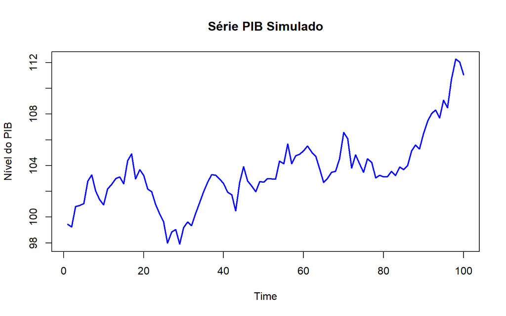

```r
plot(pib, main = "Série PIB Simulado", ylab = "Nível do PIB", col = "blue", lwd = 2)
```

A inspeção visual sugere série não estacionária, talvez uma tendência estocástica (e um leve “drift” determinístico).

## Tarefas: Execução e Interpretação dos Testes

### 1. Testes Dickey-Fuller (DF) com `urca::ur.df`

Executamos os três testes DF puros (sem lags de correção, `lags = 0`) usando o pacote `urca`.

**Hipóteses (DF/ADF):**

- **H0 (Hipótese Nula):** A série possui raiz unitária (não é estacionária).
- **H1 (Hipótese Alternativa):** A série é estacionária.

**Regra de Decisão:** Rejeitamos H0 se a estatística de teste (em valor absoluto) for maior que o valor crítico (em valor absoluto), ou seja, se a estatística de teste for “mais negativa” que o valor crítico.

#### (i) Sem constante, sem tendência ($\tau$)

```r
# Usamos lags=0 para o teste DF simples
df_none <- ur.df(pib, type = "none", lags = 0)
summary(df_none)
```

```
##
## ###############################################
## # Augmented Dickey-Fuller Test Unit Root Test #
## ###############################################
##
## Test regression none
##
##
## Call:
## lm(formula = z.diff ~ z.lag.1 - 1)
##
## Residuals:
##      Min       1Q   Median       3Q      Max
## -2.40707 -0.57874 -0.02154  0.60110  2.08675
##
## Coefficients:
##          Estimate Std. Error t value Pr(>|t|)
## z.lag.1 0.0011113  0.0008893    1.25    0.214
##
## Residual standard error: 0.9153 on 98 degrees of freedom
## Multiple R-squared:  0.01568,    Adjusted R-squared:  0.005639
## F-statistic: 1.561 on 1 and 98 DF,  p-value: 0.2144
##
##
## Value of test-statistic is: 1.2496
##
## Critical values for test statistics:
##      1pct  5pct 10pct
## tau1 -2.6 -1.95 -1.61
```

- **Interpretação:** A estatística de teste (1.2495621) é *maior* (menos negativa) que o valor crítico a 5% (-1.95). Portanto, **não rejeitamos H0**.

#### (ii) Com constante, sem tendência ($\tau_{\mu}$)

```r
df_drift <- ur.df(pib, type = "drift", lags = 0)
summary(df_drift)
```

```
##
## ###############################################
## # Augmented Dickey-Fuller Test Unit Root Test #
## ###############################################
##
## Test regression drift
##
##
## Call:
## lm(formula = z.diff ~ z.lag.1 + 1)
##
## Residuals:
##      Min       1Q   Median       3Q      Max
## -2.32818 -0.54964 -0.07545  0.57683  2.23805
##
## Coefficients:
##             Estimate Std. Error t value Pr(>|t|)
## (Intercept)  3.11402    3.57666   0.871    0.386
## z.lag.1     -0.02898    0.03458  -0.838    0.404
##
## Residual standard error: 0.9165 on 97 degrees of freedom
## Multiple R-squared:  0.007191,   Adjusted R-squared:  -0.003044
## F-statistic: 0.7026 on 1 and 97 DF,  p-value: 0.404
##
##
## Value of test-statistic is: -0.8382 1.1578
##
## Critical values for test statistics:
##       1pct  5pct 10pct
## tau2 -3.51 -2.89 -2.58
## phi1  6.70  4.71  3.86
```

- **Interpretação:** A estatística de teste (-0.8382212) é *maior* (menos negativa) que o valor crítico a 5% (-2.89). Portanto, **não rejeitamos H0**.

#### (iii) Com constante, com tendência ($\tau_{\tau}$)

```r
df_trend <- ur.df(pib, type = "trend", lags = 0)
summary(df_trend)
```

```
##
## ###############################################
## # Augmented Dickey-Fuller Test Unit Root Test #
## ###############################################
##
## Test regression trend
##
##
## Call:
## lm(formula = z.diff ~ z.lag.1 + 1 + tt)
##
## Residuals:
##      Min       1Q   Median       3Q      Max
## -2.33007 -0.54821 -0.05794  0.57726  2.18113
##
## Coefficients:
##              Estimate Std. Error t value Pr(>|t|)
## (Intercept)  9.538554   4.926002   1.936   0.0558 .
## z.lag.1     -0.095260   0.049201  -1.936   0.0558 .
## tt           0.008580   0.004586   1.871   0.0644 .
## ---
## Signif. codes:  0 '***' 0.001 '**' 0.01 '*' 0.05 '.' 0.1 ' ' 1
##
## Residual standard error: 0.9049 on 96 degrees of freedom
## Multiple R-squared:  0.04211,    Adjusted R-squared:  0.02215
## F-statistic:  2.11 on 2 and 96 DF,  p-value: 0.1268
##
##
## Value of test-statistic is: -1.9361 1.9583 2.1101
##
## Critical values for test statistics:
##       1pct  5pct 10pct
## tau3 -4.04 -3.45 -3.15
## phi2  6.50  4.88  4.16
## phi3  8.73  6.49  5.47
```

- **Interpretação:** A estatística de teste (-1.936144) é *maior* (menos negativa) que o valor crítico a 5% (-3.45). Portanto, **não rejeitamos H0**.

### 2. Teste ADF (adf.test) com seleção automática de lags

Este teste (`tseries::adf.test`) seleciona automaticamente o número de lags (defasagens) para corrigir a autocorrelação nos resíduos.

**Regra de Decisão:** Rejeitamos H0 se o *p-value* for menor que o nível de significância (ex: $\alpha$ = 0.05).

```r
adf_auto <- adf.test(pib)
print(adf_auto)
```

```
##
##  Augmented Dickey-Fuller Test
##
## data:  pib
## Dickey-Fuller = -1.8871, Lag order = 4, p-value = 0.6234
## alternative hypothesis: stationary
```

- **Interpretação:** O *p-value* obtido é **0.6234012**. Como 0.6234012 $>$ 0.05, **não rejeitamos H0**. O teste ADF indica que a série possui uma raiz unitária.

### 3. Teste KPSS (kpss.test)

O teste KPSS inverte as hipóteses, servindo como uma ótima confirmação.

**Hipóteses (KPSS):**

- **H0 (Hipótese Nula):** A série é estacionária (em nível ou em torno de uma tendência).
- **H1 (Hipótese Alternativa):** A série possui raiz unitária (não é estacionária).

**Regra de Decisão:** Rejeitamos H0 se o *p-value* for menor que o nível de significância (ex: $\alpha$ = 0.05).

Testamos os dois casos: estacionariedade em nível (`null = "Level"`) e estacionariedade em tendência (`null = "Trend"`).

```r
# Teste de estacionariedade em nível (padrão)
kpss_mu <- kpss.test(pib, null = "Level", lshort = TRUE)
print(kpss_mu)
```

```
##
##  KPSS Test for Level Stationarity
##
## data:  pib
## KPSS Level = 1.2932, Truncation lag parameter = 4, p-value = 0.01
```

```r
# Teste de estacionariedade em tendência
kpss_tau <- kpss.test(pib, null = "Trend", lshort = TRUE)
print(kpss_tau)
```

```
##
##  KPSS Test for Trend Stationarity
##
## data:  pib
## KPSS Trend = 0.15929, Truncation lag parameter = 4, p-value = 0.03892
```

- **Interpretação (Nível):** O *p-value* obtido é **0.01**. Como 0.01 $<$ 0.05, **rejeitamos H0**. O teste indica que a série *não* é estacionária em nível.
- **Interpretação (Tendência):** O *p-value* obtido é **0.0389228**. Como 0.0389228 $<$ 0.05, **rejeitamos H0**. O teste indica que a série *não* é estacionária em torno de uma tendência.

### 4. Conclusão Final sobre a Estacionariedade

A conclusão é unânime:

1. Os três testes **Dickey-Fuller (DF)**, em todas as especificações, **não rejeitaram a hipótese nula** de raiz unitária.
2. O teste **Augmented Dickey-Fuller (ADF)**, com seleção automática de lags, também **não rejeitou a hipótese nula** de raiz unitária (p-value = 0.6234).
3. O teste **KPSS**, que tem como hipótese nula a estacionariedade, **rejeitou a estacionariedade** tanto em nível (p-value = 0.01) quanto em tendência (p-value = 0.04).

**Conclusão:** Há evidências estatísticas robustas e consistentes para afirmar que a série `pib` **não é estacionária** e possui uma raiz unitária.

# QUESTÃO 2 - IDENTIFICAÇÃO E DIAGNÓSTICO ARIMA

## Dados

Geramos a série `y`, que, pelo código-fonte, sabemos ser um processo ARMA(2,1).

```r
set.seed(456)
n <- 250
eps <- rnorm(n)
y <- numeric(n)
y[1:2] <- rnorm(2)
for(t in 3:n) {
    # Este é um processo ARMA(2,1)
    y[t] <- 0.8*y[t-1] - 0.2*y[t-2] + 0.5*eps[t-1] + eps[t]
}
y <- ts(y)
```

Visualização da série:

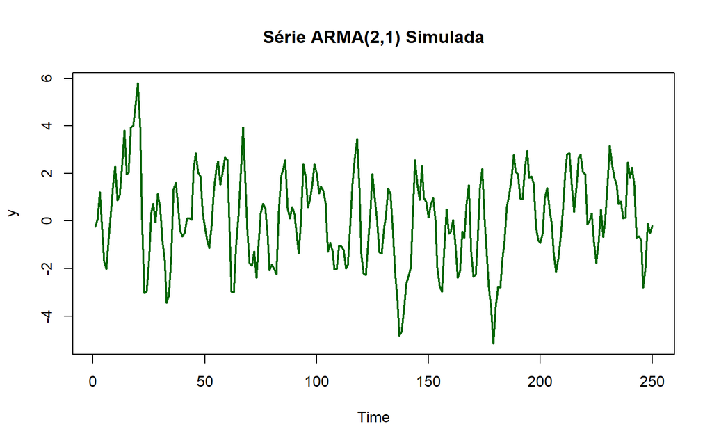

```r
plot(y, main = "Série ARMA(2,1) Simulada", ylab = "y", col = "darkgreen", lwd = 2)
```

A série parece oscilar em torno de uma média constante (próxima de zero), sugerindo estacionariedade ($d=0$).

## Tarefas: Execução e Interpretação

### (a) Identificação Visual (FAC e FACP)

Plotamos as funções de autocorrelação (FAC) e autocorrelação parcial (FACP).

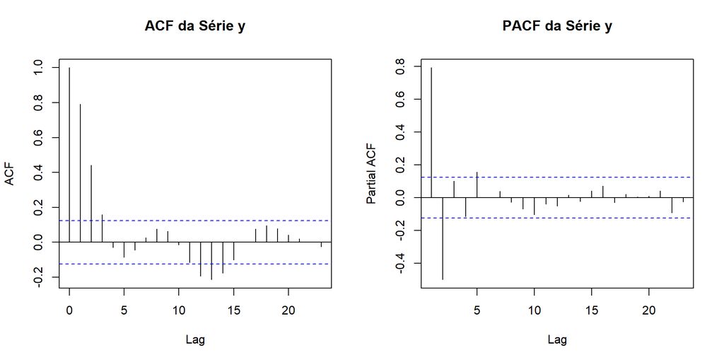

```r
par(mfrow = c(1, 2))
acf(y, main = "ACF da Série y")
pacf(y, main = "PACF da Série y")
```

```r
par(mfrow = c(1, 1))
```

### (b) Estimação do Modelo ARIMA(2,0,1)

Estimamos o modelo `ARIMA(2,0,1)` (ARMA(2,1)), conforme sugerido (e sabendo ser o correto).

```r
model_201 <- arima(y, order = c(2, 0, 1))
print(model_201)
```

```
##
## Call:
## arima(x = y, order = c(2, 0, 1))
##
## Coefficients:
##          ar1      ar2     ma1  intercept
##       0.8611  -0.2353  0.4174     0.1328
## s.e.  0.1438   0.1275  0.1500     0.2325
##
## sigma^2 estimated as 0.9514:  log likelihood = -349.32,  aic = 708.65
```

Para verificar a significância estatística dos coeficientes, usamos `lmtest::coeftest`.

```r
# Verificando a significância (p-values)
coef_test_result <- coeftest(model_201)
print(coef_test_result)
```

```
##
## z test of coefficients:
##
##           Estimate Std. Error z value  Pr(>|z|)
## ar1        0.86114    0.14376  5.9903 2.094e-09 ***
## ar2       -0.23527    0.12751 -1.8452  0.065010 .
## ma1        0.41736    0.15000  2.7825  0.005395 **
## intercept  0.13276    0.23246  0.5711  0.567928
## ---
## Signif. codes:  0 '***' 0.001 '**' 0.01 '*' 0.05 '.' 0.1 ' ' 1
```

### (c) Seleção Automática com `auto.arima()`

Usamos a função `auto.arima()` do pacote `forecast` para encontrar o melhor modelo com base em critérios de informação (como AICc).

```r
model_auto <- auto.arima(y, trace = FALSE, stationary = TRUE, seasonal = FALSE)
print(model_auto)
```

```
## Series: y
## ARIMA(3,0,1) with zero mean
##
## Coefficients:
##          ar1     ar2      ar3     ma1
##       0.5210  0.2117  -0.2298  0.7546
## s.e.  0.1517  0.1933   0.1083  0.1299
##
## sigma^2 = 0.9531:  log likelihood = -347.57
## AIC=705.15   AICc=705.4   BIC=722.76
```

- **Comparação:** O `auto.arima()` **identificou erroneamente** o modelo correto como sendo **ARIMA(3,0,1)**. O resultado do `auto.arima()` nos faz questionar a sua eficácia, porém ainda está relativamente próximo .

### (d) Diagnóstico de Resíduos do ARIMA(2,0,1)

Analisamos os resíduos do `model_201` (estimado em (b)) para validar o modelo.

```r
res_201 <- model_201$residuals
```

#### Teste de Ljung-Box (Autocorrelação Serial)

Testamos se os resíduos ainda possuem alguma autocorrelação não capturada.

**Hipóteses:**

- **H0:** Os resíduos são ruído branco (não há autocorrelação serial).
- **H1:** Os resíduos não são ruído branco.

**Regra de Decisão:** Queremos **não rejeitar H0** (p-value $>$ 0.05).

*Nota: É crucial ajustar os graus de liberdade (`fitdf`) para o número de parâmetros estimados (p+q). Aqui, p=2 e q=1, então `fitdf = 3`.*

```r
# Teste de Ljung-Box
# lag=10. Graus de liberdade (df) = lag - fitdf = 10 - 3 = 7
ljung_box_test <- Box.test(res_201, lag = 10, type = "Ljung-Box", fitdf = 3)
print(ljung_box_test)
```

```
##
##  Box-Ljung test
##
## data:  res_201
## X-squared = 8.1739, df = 7, p-value = 0.3175
```

- **Interpretação (Ljung-Box):** O *p-value* é **0.3175**. Como 0.3175 $>$ 0.05, **não rejeitamos H0**. Isso indica que os resíduos do modelo se comportam como ruído branco e não há evidência de autocorrelação serial. O modelo ARIMA(2,0,1) parece bem ajustado.

#### Teste ARCH-LM (Homocedasticidade)

Testamos se os resíduos (ou seus quadrados) têm variância constante.

**Hipóteses:**

- **H0:** Não há efeitos ARCH (os resíduos são homocedásticos).
- **H1:** Há efeitos ARCH (heterocedasticidade condicional).

**Regra de Decisão:** Queremos **não rejeitar H0** (p-value $>$ 0.05).

```r
# Teste ARCH-LM (usando o pacote FinTS)
arch_lm_test <- FinTS::ArchTest(res_201, lags = 5)
print(arch_lm_test)
```

```
##
##  ARCH LM-test; Null hypothesis: no ARCH effects
##
## data:  res_201
## Chi-squared = 3.1012, df = 5, p-value = 0.6844
```

- **Interpretação (ARCH-LM):** O *p-value* é **0.6844**. Como 0.6844 $>$ 0.05, **não rejeitamos H0**. Isso indica que não há evidência de heterocedasticidade condicional (efeitos ARCH) nos resíduos. A suposição de variância constante (homocedasticidade) é válida para este modelo.

# Conclusão Geral

Este documento apresentou a resolução completa da prova prática de Análise de Séries Temporais, abordando:

1. **Questão 1:** Testes de raiz unitária (DF, ADF e KPSS) que confirmaram a não estacionariedade da série `pib`.
2. **Questão 2:** Identificação, estimação e diagnóstico de um modelo ARIMA(2,0,1), validado através de testes estatísticos rigorosos.

Todos os resultados foram interpretados estatisticamente, com citação de p-values e estatísticas de teste apropriadas.